```python
# This Python 3 environment comes with many helpful analytics libraries installed
# It is defined by the kaggle/python Docker image: https://github.com/kaggle/docker-python
# For example, here's several helpful packages to load

import numpy as np # linear algebra
import pandas as pd # data processing, CSV file I/O (e.g. pd.read_csv)

# Input data files are available in the read-only "../input/" directory
# For example, running this (by clicking run or pressing Shift+Enter) will list all files under the input directory

import os
for dirname, _, filenames in os.walk('/kaggle/input'):
    for filename in filenames:
        print(os.path.join(dirname, filename))

# You can write up to 5GB to the current directory (/kaggle/working/) that gets preserved as output when you create a version using "Save & Run All"
# You can also write temporary files to /kaggle/temp/, but they won't be saved outside of the current session
```

```
/kaggle/input/sf-crime/train.csv.zip
/kaggle/input/sf-crime/test.csv.zip
/kaggle/input/sf-crime/sampleSubmission.csv.zip
```

# Insights

Lets start by visualising the datasets in pandas

```python
test_set_full_raw = pd.read_csv("../input/sf-crime/test.csv.zip", compression="zip", index_col='Id')
train_set_full_raw = pd.read_csv("../input/sf-crime/train.csv.zip", compression="zip")
```

```python
train_set_full_raw.head()
```

|  | Dates | Category | Descript | DayOfWeek | PdDistrict | Resolution | Address | X | Y |
| --- | --- | --- | --- | --- | --- | --- | --- | --- | --- |
| 0 | 2015-05-13 23:53:00 | WARRANTS | WARRANT ARREST | Wednesday | NORTHERN | ARREST, BOOKED | OAK ST / LAGUNA ST | -122.425892 | 37.774599 |
| 1 | 2015-05-13 23:53:00 | OTHER OFFENSES | TRAFFIC VIOLATION ARREST | Wednesday | NORTHERN | ARREST, BOOKED | OAK ST / LAGUNA ST | -122.425892 | 37.774599 |
| 2 | 2015-05-13 23:33:00 | OTHER OFFENSES | TRAFFIC VIOLATION ARREST | Wednesday | NORTHERN | ARREST, BOOKED | VANNESS AV / GREENWICH ST | -122.424363 | 37.800414 |
| 3 | 2015-05-13 23:30:00 | LARCENY/THEFT | GRAND THEFT FROM LOCKED AUTO | Wednesday | NORTHERN | NONE | 1500 Block of LOMBARD ST | -122.426995 | 37.800873 |
| 4 | 2015-05-13 23:30:00 | LARCENY/THEFT | GRAND THEFT FROM LOCKED AUTO | Wednesday | PARK | NONE | 100 Block of BRODERICK ST | -122.438738 | 37.771541 |

```python
#Check what columns are present in the test set.
train_set_full_raw.columns
```

```
Index(['Dates', 'Category', 'Descript', 'DayOfWeek', 'PdDistrict',
       'Resolution', 'Address', 'X', 'Y'],
      dtype='object')
```

We will check if the train set contains any null values or missing rows. The data looks fine here so no data cleaning needed.

```python
train_set_full_raw.info()
```

```
<class 'pandas.core.frame.DataFrame'>
RangeIndex: 878049 entries, 0 to 878048
Data columns (total 9 columns):
 #   Column      Non-Null Count   Dtype
---  ------      --------------   -----
 0   Dates       878049 non-null  object
 1   Category    878049 non-null  object
 2   Descript    878049 non-null  object
 3   DayOfWeek   878049 non-null  object
 4   PdDistrict  878049 non-null  object
 5   Resolution  878049 non-null  object
 6   Address     878049 non-null  object
 7   X           878049 non-null  float64
 8   Y           878049 non-null  float64
dtypes: float64(2), object(7)
memory usage: 60.3+ MB
```

```python
train_set_full_raw.describe()
```

|  | X | Y |
| --- | --- | --- |
| count | 878049.000000 | 878049.000000 |
| mean | -122.422616 | 37.771020 |
| std | 0.030354 | 0.456893 |
| min | -122.513642 | 37.707879 |
| 25% | -122.432952 | 37.752427 |
| 50% | -122.416420 | 37.775421 |
| 75% | -122.406959 | 37.784369 |
| max | -120.500000 | 90.000000 |

However, looking at the summary of X, Y columns, there seems to be an outlier. Most of the Y falls around the 37 range but there is one at 90. Lets remove the 90 from our dataset

```python
ts = train_set_full_raw.copy()
ts = ts[ts["Y"]<90]
```

By plotting the X, Y coordinates we can see that the crimes cluster at certain regions of SF.

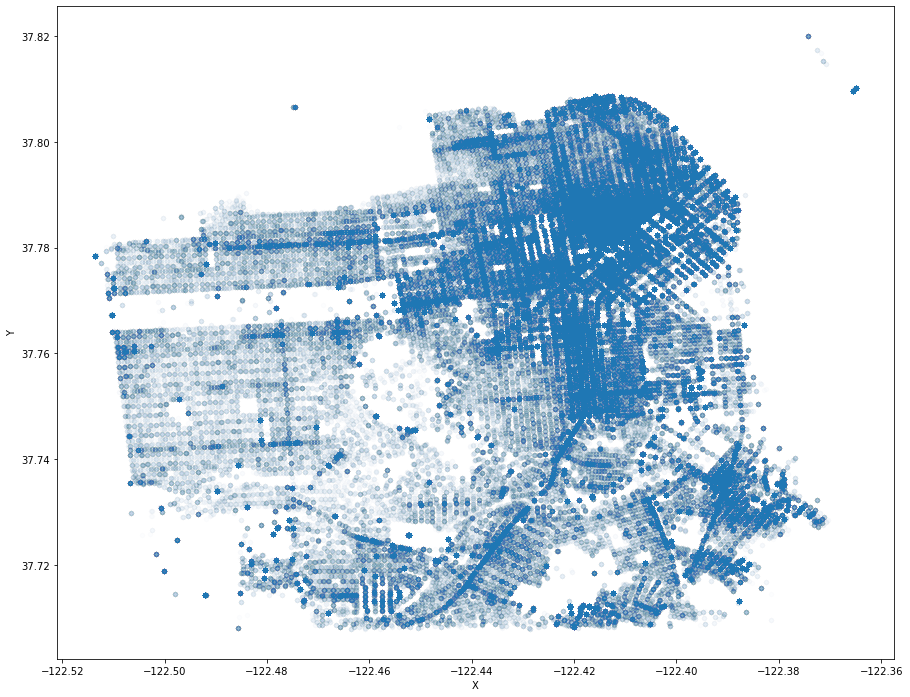

```python
ts.plot(x="X", y="Y", kind="scatter", alpha=0.01,figsize=(15,12))
```

We can also see the most common crime categories recorded and what are their most common resolutions

```python
ts["Category"].value_counts()
```

```
LARCENY/THEFT                  174885
OTHER OFFENSES                 126165
NON-CRIMINAL                    92300
ASSAULT                         76872
DRUG/NARCOTIC                   53971
VEHICLE THEFT                   53772
VANDALISM                       44724
WARRANTS                        42206
BURGLARY                        36754
SUSPICIOUS OCC                  31412
MISSING PERSON                  25989
ROBBERY                         22999
FRAUD                           16679
FORGERY/COUNTERFEITING          10609
SECONDARY CODES                  9985
WEAPON LAWS                      8555
PROSTITUTION                     7484
TRESPASS                         7325
STOLEN PROPERTY                  4539
SEX OFFENSES FORCIBLE            4387
DISORDERLY CONDUCT               4318
DRUNKENNESS                      4280
RECOVERED VEHICLE                3138
KIDNAPPING                       2341
DRIVING UNDER THE INFLUENCE      2268
RUNAWAY                          1946
LIQUOR LAWS                      1903
ARSON                            1513
LOITERING                        1225
EMBEZZLEMENT                     1166
SUICIDE                           508
FAMILY OFFENSES                   491
BAD CHECKS                        406
BRIBERY                           289
EXTORTION                         256
SEX OFFENSES NON FORCIBLE         148
GAMBLING                          146
PORNOGRAPHY/OBSCENE MAT            22
TREA                                6
Name: Category, dtype: int64
```

```python
print("Most common resolutions for each category in percentage\n")
for i in ts.groupby(["Category"])["Resolution"]:
  print('\033[95m'+i[0]+'\033[0m')
  print(round(i[1].value_counts()[:3]/i[1].count()*100,1))
  print()
```

```
Most common resolutions for each category in percentage

ARSON
NONE               82.5
ARREST, BOOKED     13.4
JUVENILE BOOKED     1.1
Name: Resolution, dtype: float64

ASSAULT
NONE              58.2
ARREST, BOOKED    30.5
ARREST, CITED      4.6
Name: Resolution, dtype: float64

BAD CHECKS
NONE                            79.1
PROSECUTED BY OUTSIDE AGENCY     6.2
ARREST, BOOKED                   6.2
Name: Resolution, dtype: float64

BRIBERY
ARREST, BOOKED                            55.0
NONE                                      37.4
DISTRICT ATTORNEY REFUSES TO PROSECUTE     2.1
Name: Resolution, dtype: float64

BURGLARY
NONE              83.9
ARREST, BOOKED    13.2
UNFOUNDED          0.7
Name: Resolution, dtype: float64

DISORDERLY CONDUCT
ARREST, BOOKED    34.9
NONE              31.6
ARREST, CITED     31.0
Name: Resolution, dtype: float64

DRIVING UNDER THE INFLUENCE
ARREST, BOOKED    85.5
```

[output cut: 179 more lines]

```
UNFOUNDED          4.0
ARREST, BOOKED     3.8
Name: Resolution, dtype: float64

WARRANTS
ARREST, BOOKED     91.9
NONE                5.2
JUVENILE BOOKED     1.5
Name: Resolution, dtype: float64

WEAPON LAWS
ARREST, BOOKED    56.7
NONE              27.5
ARREST, CITED      6.9
Name: Resolution, dtype: float64
```

The dataset gave us the dates of the crime. However, a more useful feature would be the hour the crime occured. Therefore, lets add it to our dataset.

```python
from datetime import datetime

ts["Hour"] = ts.Dates.apply(lambda date_string: date_string[11:-6])
ts.head()
```

|  | Dates | Category | Descript | DayOfWeek | PdDistrict | Resolution | Address | X | Y | Hour |
| --- | --- | --- | --- | --- | --- | --- | --- | --- | --- | --- |
| 0 | 2015-05-13 23:53:00 | WARRANTS | WARRANT ARREST | Wednesday | NORTHERN | ARREST, BOOKED | OAK ST / LAGUNA ST | -122.425892 | 37.774599 | 23 |
| 1 | 2015-05-13 23:53:00 | OTHER OFFENSES | TRAFFIC VIOLATION ARREST | Wednesday | NORTHERN | ARREST, BOOKED | OAK ST / LAGUNA ST | -122.425892 | 37.774599 | 23 |
| 2 | 2015-05-13 23:33:00 | OTHER OFFENSES | TRAFFIC VIOLATION ARREST | Wednesday | NORTHERN | ARREST, BOOKED | VANNESS AV / GREENWICH ST | -122.424363 | 37.800414 | 23 |
| 3 | 2015-05-13 23:30:00 | LARCENY/THEFT | GRAND THEFT FROM LOCKED AUTO | Wednesday | NORTHERN | NONE | 1500 Block of LOMBARD ST | -122.426995 | 37.800873 | 23 |
| 4 | 2015-05-13 23:30:00 | LARCENY/THEFT | GRAND THEFT FROM LOCKED AUTO | Wednesday | PARK | NONE | 100 Block of BRODERICK ST | -122.438738 | 37.771541 | 23 |

Lets see which day of the week and hour crime occurs the most:

```python
ts.groupby(["DayOfWeek"])["Hour"].value_counts()
```

```
DayOfWeek  Hour
Friday     18      8711
           17      8381
           19      7785
           12      7774
           16      7658
                   ...
Wednesday  02      2377
           06      2054
           03      1701
           05      1303
           04      1268
Name: Hour, Length: 168, dtype: int64
```

# Preprocessing

Now we can start preparing our dataset for training. We will only extract the relevant columns into our train and test set.

```python
import numpy as np

train_full = ts.copy()
X_train_full, y_train_full = np.array(train_full[["DayOfWeek", "PdDistrict", "X", "Y", "Hour"]]), np.array(train_full[["Category"]])
y_train_full = y_train_full.ravel()
X_test = test_set_full_raw.copy()
X_test["Hour"] = X_test.Dates.apply(lambda date_string: date_string[11:-6])
X_test = X_test.drop(columns=["Dates", "Address"])
X_test = np.array(X_test)
```

We further split the full training set into train and validation set. We use Stratified sampling to ensure that the training and val set contains a proper representation of the categories present in the total population

```python
import sklearn
from sklearn.model_selection import StratifiedShuffleSplit

sss = StratifiedShuffleSplit(n_splits=1, test_size=0.25, random_state=42)

for train_index, test_index in sss.split(X_train_full, y_train_full):
  X_train, y_train = X_train_full[train_index], y_train_full[train_index]
  X_val, y_val = X_train_full[test_index], y_train_full[test_index]
```

Next, lets set a pipeline to preprocess the datasets. StandardScaler() to normalise the numerical atttributes and OneHotEncoder() to convert the categorical attributes to arrays.

```python
from sklearn.pipeline import Pipeline
from sklearn.preprocessing import StandardScaler, OneHotEncoder
from sklearn.compose import ColumnTransformer

num_attribs = [2,3]
cat_attribs = [0,1,4]

num_pipeline = Pipeline([
                         ('std_scaler', StandardScaler())
])

full_pipeline = ColumnTransformer([
                                 ('num', num_pipeline, num_attribs),
                                 ('cat', OneHotEncoder(), cat_attribs)
])

X_train_prepared = full_pipeline.fit_transform(X_train)
X_val_prepared = full_pipeline.transform(X_val)
X_test_prepared = full_pipeline.transform(X_test)
```

# Select and train model

```python
from sklearn.svm import LinearSVC
from sklearn.ensemble import RandomForestClassifier,VotingClassifier
import xgboost
```

```python
X_train_prepared.shape
```

```
(658486, 43)
```

The train set contains 658 486 rows which lead to slow training time for me. Therefore, we will reduce the training set to 100 000 rows use Stratified Sampling again to get a good representation of the population.

```python
ss = StratifiedShuffleSplit(n_splits=1, train_size=100_000, random_state=42)
for train_index, _ in ss.split(X_train_prepared, y_train):
  X_train_prepared_small, y_train_small = X_train_prepared[train_index], y_train[train_index].ravel()

X_train_prepared_small.shape, y_train_small.shape
```

```
((100000, 43), (100000,))
```

Ensemble Learning aggregates the prediction of a group of predictors. We usually get better results from it compared with just a single best individual predictor.

From a prior, not very thorough, testing with different classifiers such as LinearSVC, BaggingClassifier, ExtraTreesClassifier. I found that Ensemble learning with XGBoost and RandomForest yield the best results.

```python
rf_clf = RandomForestClassifier(max_depth=16, random_state=42, n_jobs=-1, verbose=3)
xg_clf = xgboost.XGBClassifier()

estimators = [
            ("rf", rf_clf),
            ("xg", xg_clf)
]

voting_clf = VotingClassifier(estimators, n_jobs=-1, voting="soft")
voting_clf.fit(X_train_prepared_small, y_train_small)
voting_clf.score(X_val_prepared, y_val)
```

```
[Parallel(n_jobs=4)]: Using backend ThreadingBackend with 4 concurrent workers.
[Parallel(n_jobs=4)]: Done  24 tasks      | elapsed:    0.9s
[Parallel(n_jobs=4)]: Done 100 out of 100 | elapsed:    3.3s finished
```

```
0.2659866239020301
```

Finally, lets create the csv file for submission. This submission should give us a score of about 2.506:

```python
y_pred = voting_clf.predict_proba(X_test_prepared)
pred_df = pd.DataFrame(y_pred, columns=[voting_clf.classes_])
pred_df["Id"]= list(range(pred_df.shape[0]))
pred_df.to_csv("crime_pred_02.zip", compression="zip", index=False)
pred_df.head()
```

```
[Parallel(n_jobs=4)]: Using backend ThreadingBackend with 4 concurrent workers.
[Parallel(n_jobs=4)]: Done  24 tasks      | elapsed:    3.5s
[Parallel(n_jobs=4)]: Done 100 out of 100 | elapsed:   12.9s finished
```

|  | ARSON | ASSAULT | BAD CHECKS | BRIBERY | BURGLARY | DISORDERLY CONDUCT | DRIVING UNDER THE INFLUENCE | DRUG/NARCOTIC | DRUNKENNESS | EMBEZZLEMENT | ... | STOLEN PROPERTY | SUICIDE | SUSPICIOUS OCC | TREA | TRESPASS | VANDALISM | VEHICLE THEFT | WARRANTS | WEAPON LAWS | Id |
| --- | --- | --- | --- | --- | --- | --- | --- | --- | --- | --- | --- | --- | --- | --- | --- | --- | --- | --- | --- | --- | --- |
| 0 | 0.002600 | 0.092769 | 0.000130 | 0.000276 | 0.022762 | 0.001422 | 0.002095 | 0.027841 | 0.002173 | 0.000773 | ... | 0.014149 | 0.000085 | 0.022919 | 6.997829e-07 | 0.002507 | 0.073337 | 0.130898 | 0.049242 | 0.013172 | 0 |
| 1 | 0.004448 | 0.120573 | 0.000145 | 0.000698 | 0.014472 | 0.001840 | 0.005577 | 0.095367 | 0.003332 | 0.000241 | ... | 0.002835 | 0.000099 | 0.025346 | 6.374235e-07 | 0.003044 | 0.059236 | 0.054834 | 0.088342 | 0.032687 | 1 |
| 2 | 0.000588 | 0.063818 | 0.000083 | 0.000024 | 0.081312 | 0.001652 | 0.002970 | 0.019283 | 0.004084 | 0.000335 | ... | 0.003394 | 0.000675 | 0.024432 | 6.033798e-07 | 0.004649 | 0.066084 | 0.105820 | 0.025941 | 0.004329 | 2 |
| 3 | 0.001465 | 0.102073 | 0.000262 | 0.000278 | 0.018288 | 0.001526 | 0.004698 | 0.031347 | 0.002733 | 0.002787 | ... | 0.008294 | 0.000525 | 0.025992 | 2.303354e-06 | 0.003507 | 0.070705 | 0.191155 | 0.040288 | 0.021307 | 3 |
| 4 | 0.001465 | 0.102073 | 0.000262 | 0.000278 | 0.018288 | 0.001526 | 0.004698 | 0.031347 | 0.002733 | 0.002787 | ... | 0.008294 | 0.000525 | 0.025992 | 2.303354e-06 | 0.003507 | 0.070705 | 0.191155 | 0.040288 | 0.021307 | 4 |

5 rows × 40 columns